# Trial Code

Aoi Kawahara

2025-02-28

## About trial.Rmd

本番は30万件以上のポストを扱う予定だが、使用する変数等の挙動確認のため、trialではまず1,000件のポストで分析を実行してみる。

I will deal with more than 300k posts for the actual thesis. This trial is conducted on 1k posts for the purpose of testing the code and functions below.

## Load libraries

```r
library(data.table)
library(tidyverse)
```

```r
library(tidytext)
library(wordcloud)
library(topicmodels)
library(tm)
library(dplyr)
library(qdap)
library(plotrix)
library(dendextend)
library(tokenizers)
library(textclean)
library(ggthemes)
```

## Load data

```r
setwd('/Users/aoikawahara/Library/CloudStorage/OneDrive-KULeuven/Leuven/01_Master Thesis/Workplace')

df = fread("data/part_1/may_july_chunk_1.csv.gz")
```

## Select necessary columns

```r
df <- df[1:1000,] %>%
  subset(lang == 'en') %>%
  subset(select = c(text, epoch, retweetCount, likeCount)) %>%
  mutate(id = row_number())
```

## Fast descriptives

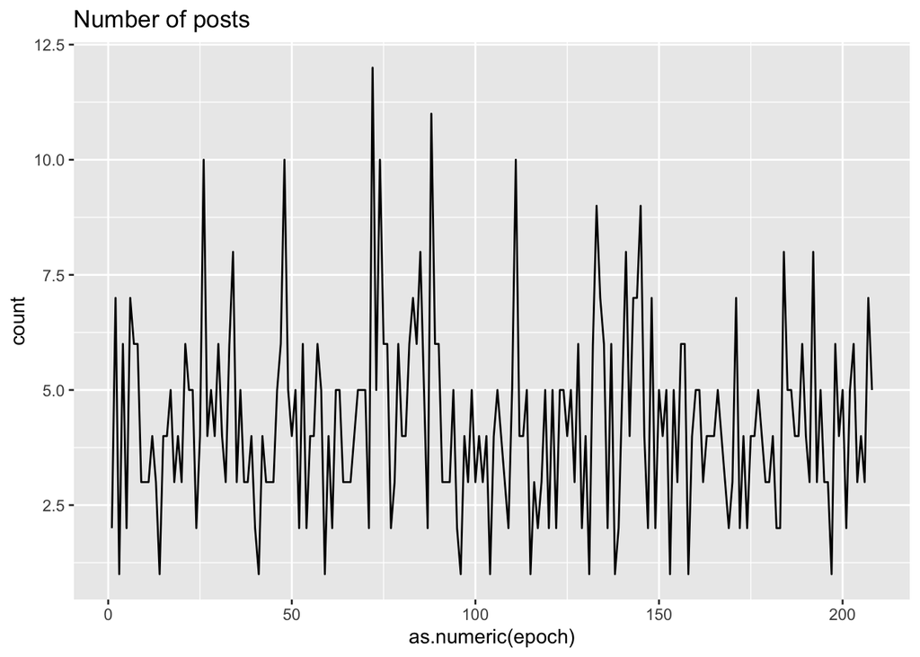

```r
df_epoch <- data.frame(table(df$epoch))
colnames(df_epoch) <- c("epoch", "count")

ggplot(df_epoch, aes(x = as.numeric(epoch), y = count)) +
  geom_line() +
  labs(title = "Number of posts")
```

## Clean text

From Kanmaz(2023)

- Lowercasing the characters
- Removal of stopwords
- Stemming the words
- Removal of hashtags
- Removal of user mentions
- Removal of links
- Removal of emojis

```r
qdap_clean <- function(x) {
  x <- replace_abbreviation(x)            　 # "Dr." → "Doctor"
  x <- replace_contraction(x)                # "can't" → "cannot"
  x <- replace_ordinal(x)                    # "1st" → "first"
  x <- gsub("\\d+", "", x)                   # Removal of numbers
  x <- tolower(x)                            # Lowercasing the characters
  x <- str_remove_all(x, "#\\S+") 　　　　　 # Removal of hashtags
  x <- str_remove_all(x, "@\\S+")  　　　　　# Removal of user mentions
  x <- replace_symbol(x)                     # "&" → "and"
  x <- str_remove_all(x, "http[s]?://\\S+")  # Removal of links
  x <- replace_emoji(x)                      # Emojis → Word forms equivalents
  return(x)
  }

tm_clean <- function(corpus) {
  corpus <- tm_map(corpus, removePunctuation)  # Remove punctuation (句読点)
  corpus <- tm_map(corpus, removeWords, stopwords("en"))    # Remove stopwords
# corpus <- tm_map(corpus, content_transformer(stemDocument))  # Stemming
  corpus <- tm_map(corpus, stripWhitespace)    # 余分な余白
  return(corpus)}

qdap_cleaned_df <- qdap_clean(df$text)
corp <- VCorpus(VectorSource(qdap_cleaned_df)) %>%
  tm_clean()

cleaned_text <- lapply(corp, function(doc) doc$content)
df_cleaned_text <- data.frame(id = seq_along(cleaned_text),
                              text = unlist(cleaned_text),
                              stringsAsFactors = FALSE)

# qdap_cleanの挙動確認
df$text[25]
```

```
## [1] "@banterwithb Biden has more people in the media trying to maintain his image, but has a lot more enemies in doing so, Francis has 1 billion Catholics religiously devoted to him but as a religious leader has more people scrutinising him or not caring in general. Biden has it worse imo"
```

```r
qdap_cleaned_df[25]
```

```
## [1] " biden has more people in the media trying to maintain his image, but has a lot more enemies in doing so, francis has billion catholics religiously devoted to him but as a religious leader has more people scrutinising him or not caring in general. biden has it worse imo"
```

```r
cleaned_text[25]
```

```
## $`25`
## [1] " biden people media trying maintain image lot enemies francis billion catholics religiously devoted religious leader people scrutinising caring general biden worse imo"
```

## Create Term Document Matrix

```r
tdm <- TermDocumentMatrix(corp)
tdm_m <- as.matrix(tdm)

tdm_m[which(is.na(tdm_m))] <- 0
```

## Plot bar chart - term frequency

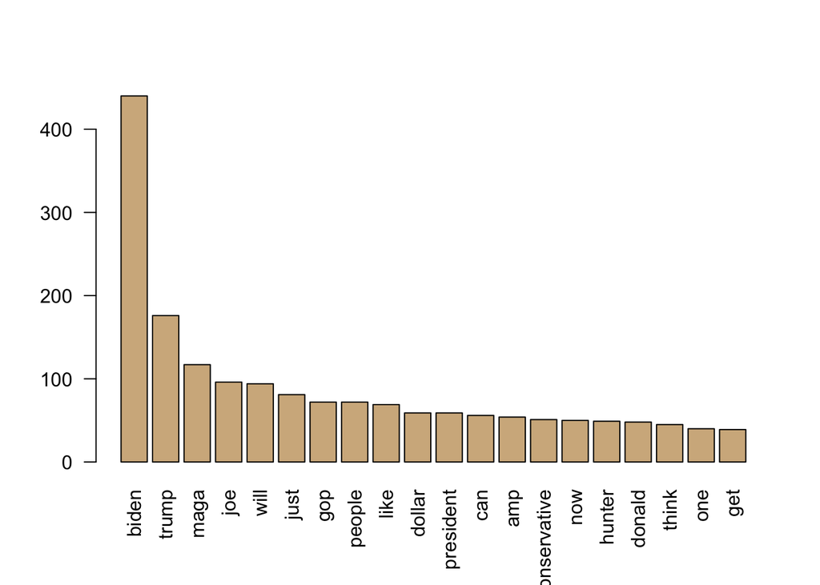

```r
freq <- rowSums(tdm_m)
freq <- sort(freq, decreasing = TRUE)

barplot(freq[1:20], col = "tan", las = 2)
```

## Plot WordCloud

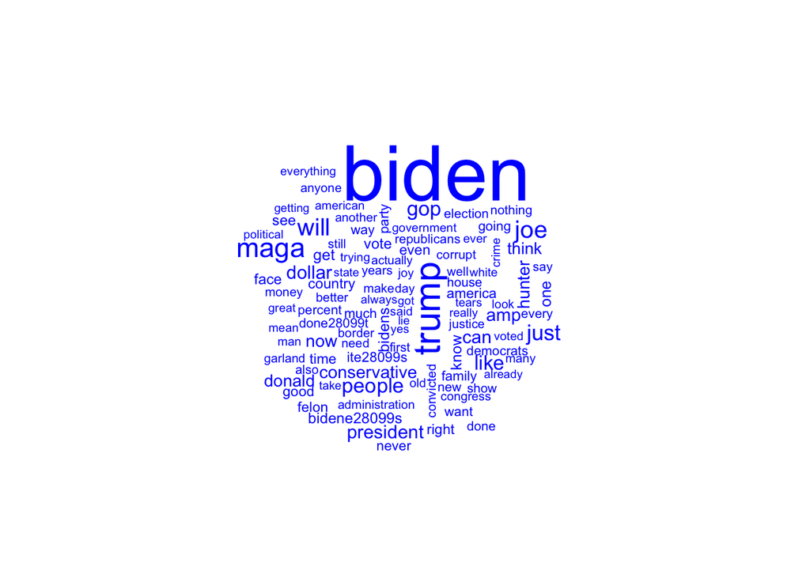

```r
wordcloud(names(freq), freq, max.words = 100, color = "blue")
```

## Word Association “biden”

```r
assoc <- findAssocs(tdm, "biden", 0.12)
assoc
```

```
## $biden
##         joe         adm     deserve   dismissed       match      robert
##        0.20        0.15        0.15        0.15        0.15        0.15
## transcripts     garland      hunter      remove        iran   pedophile
##        0.15        0.13        0.13        0.13        0.12        0.12
##        seem
##        0.12
```

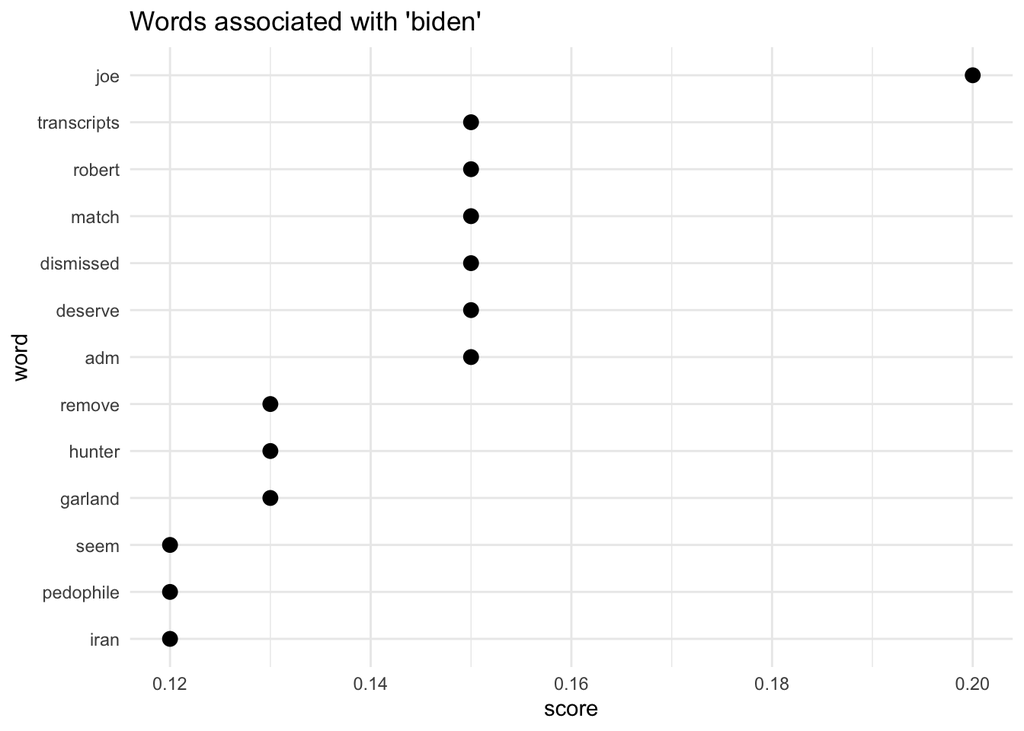

```r
assoc_df <- list_vect2df(assoc, col2 = "word", col3 = "score")

ggplot(assoc_df, aes(score, word)) +
  geom_point(size = 3) +
  labs(title = "Words associated with 'biden'") +
  theme_minimal()
```

## Word Association “trump”

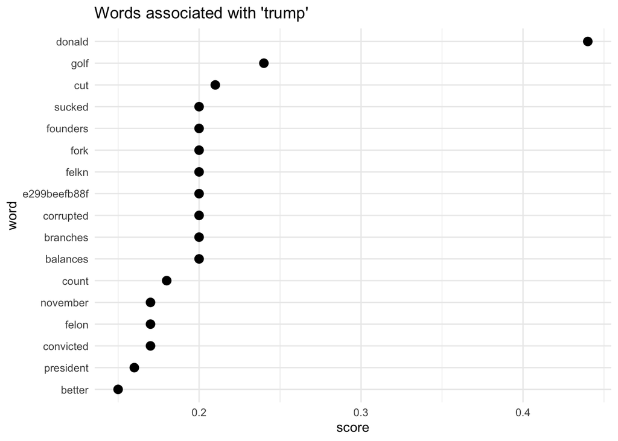

```r
assoc_trump <- findAssocs(tdm, "trump", 0.15)

assoc_trump_df <- list_vect2df(assoc_trump, col2 = "word", col3 = "score")

ggplot(assoc_trump_df, aes(score, word)) +
  geom_point(size = 3) +
  labs(title = "Words associated with 'trump'") +
  theme_minimal()
```

## LDA with 3 topics

Kanmaz(2023)は3~25 topicsで試し、coherence scoreを比較していた。

```r
dtm <- DocumentTermMatrix(corp)

row_sums <- rowSums(as.matrix(dtm))
(which(row_sums == 0))  # 342
```

```
## 342
## 342
```

```r
dtm <- dtm[row_sums > 0, ]  # 単語が含まれていない空の文書を削除

lda_3 <- LDA(dtm, k = 3, method = "Gibbs", control = list(seed = 42))

lda_3 <- lda_3 %>%
  tidy(matrix = "beta")
lda_3 %>%
  arrange(desc(beta))
```

```
## # A tibble: 12,108 × 3
##    topic term     beta
##    <int> <chr>   <dbl>
##  1     2 biden  0.104
##  2     3 trump  0.0407
##  3     3 maga   0.0274
##  4     2 joe    0.0223
##  5     2 will   0.0220
##  6     1 just   0.0200
##  7     1 gop    0.0175
##  8     2 people 0.0166
##  9     3 like   0.0162
## 10     3 dollar 0.0138
## # ℹ 12,098 more rows
```

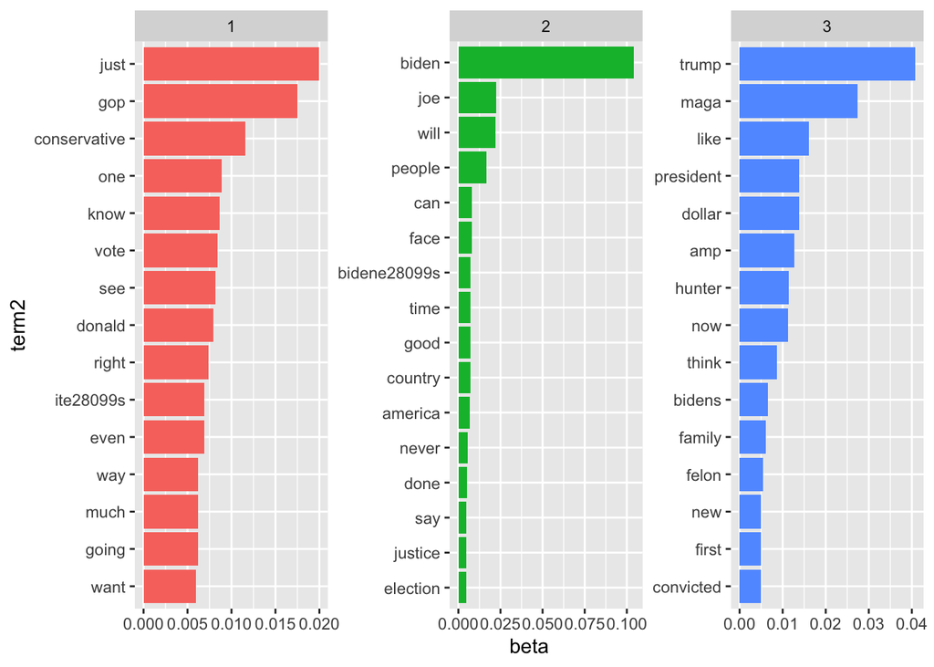

```r
# Visualization of top 15 terms by topic (3topics)
word_3 <- lda_3 %>%
  group_by(topic) %>%
  slice_max(beta, n = 15) %>%
  ungroup() %>%
  mutate(term2 = fct_reorder(term, beta))

ggplot(word_3, aes(x = term2, y = beta, fill = as.factor(topic))) +
  geom_col(show.legend = FALSE) +
  facet_wrap(~ topic, scales = "free") +
  coord_flip()
```

## Select number of topics for LDA model

(Coherence score…モデルによって生成されたトピックの一貫性と解釈可能性を評価。)

https://cran.r-project.org/web/packages/ldatuning/vignettes/topics.html

```r
library("ldatuning")

result <- FindTopicsNumber(
  dtm,
  topics = seq(from = 2, to = 15, by = 1),
  metrics = c("Griffiths2004", "CaoJuan2009", "Arun2010", "Deveaud2014"),
  method = "Gibbs",
  mc.cores = 2L,
  verbose = TRUE)
```

```
## fit models... done.
## calculate metrics:
##   Griffiths2004... done.
##   CaoJuan2009... done.
##   Arun2010... done.
##   Deveaud2014... done.
```

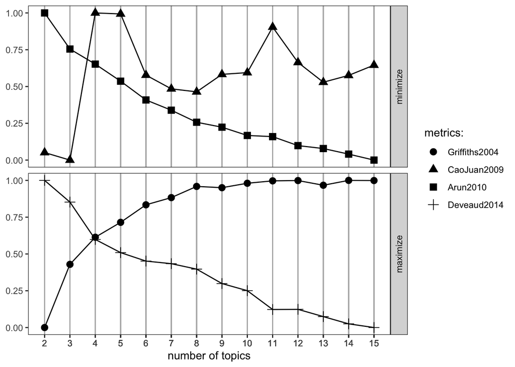

```r
FindTopicsNumber_plot(result)
```

## LDA with 5 topics

```r
lda_5 <- LDA(dtm, k = 5)
class(lda_5)
```

```
## [1] "LDA_VEM"
## attr(,"package")
## [1] "topicmodels"
```

```r
# Visualization of top 10 terms by topic (5topics)
lda_5 <- lda_5 %>%
  tidy(matrix = "beta")
lda_5 %>%
  arrange(desc(beta))
```

```
## # A tibble: 20,180 × 3
##    topic term     beta
##    <int> <chr>   <dbl>
##  1     3 biden  0.0493
##  2     5 biden  0.0425
##  3     2 biden  0.0398
##  4     1 biden  0.0342
##  5     4 biden  0.0286
##  6     5 dollar 0.0273
##  7     5 trump  0.0238
##  8     3 trump  0.0208
##  9     2 joe    0.0183
## 10     5 maga   0.0167
## # ℹ 20,170 more rows
```

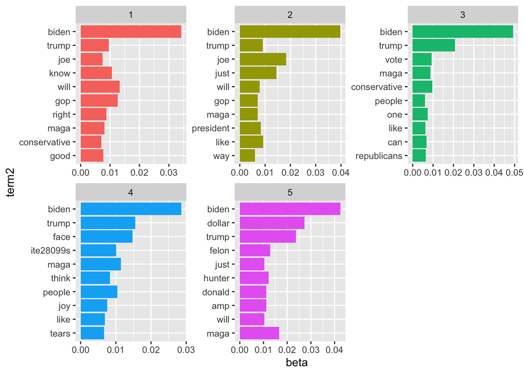

```r
word_5 <- lda_5 %>%
  group_by(topic) %>%
  slice_max(beta, n = 10) %>%
  ungroup() %>%
  mutate(term2 = fct_reorder(term, beta))

ggplot(word_5, aes(x = term2, y = beta, fill = as.factor(topic))) +
  geom_col(show.legend = FALSE) +
  facet_wrap(~ topic, scales = "free") +
  coord_flip()
```

## TF-IDF Vectorization

```r
tfidf_tdm <- TermDocumentMatrix(corp, control = list(weighting = weightTfIdf))
tfidf_tdm_m <- as.matrix(tfidf_tdm)

tfidf_tdm_m[c("biden", "trump", "maga"), 20:30]
```

```
##        Docs
## Terms   20        21         22        23 24        25 26        27         28
##   biden  0 0.3732672 0.07998582 0.0000000  0 0.1018001  0 0.1399752 0.09331679
##   trump  0 0.0000000 0.00000000 0.1962580  0 0.0000000  0 0.0000000 0.00000000
##   maga   0 0.0000000 0.00000000 0.1186552  0 0.0000000  0 0.0000000 0.00000000
##        Docs
## Terms          29 30
##   biden 0.0000000  0
##   trump 0.1342818  0
##   maga  0.0000000  0
```

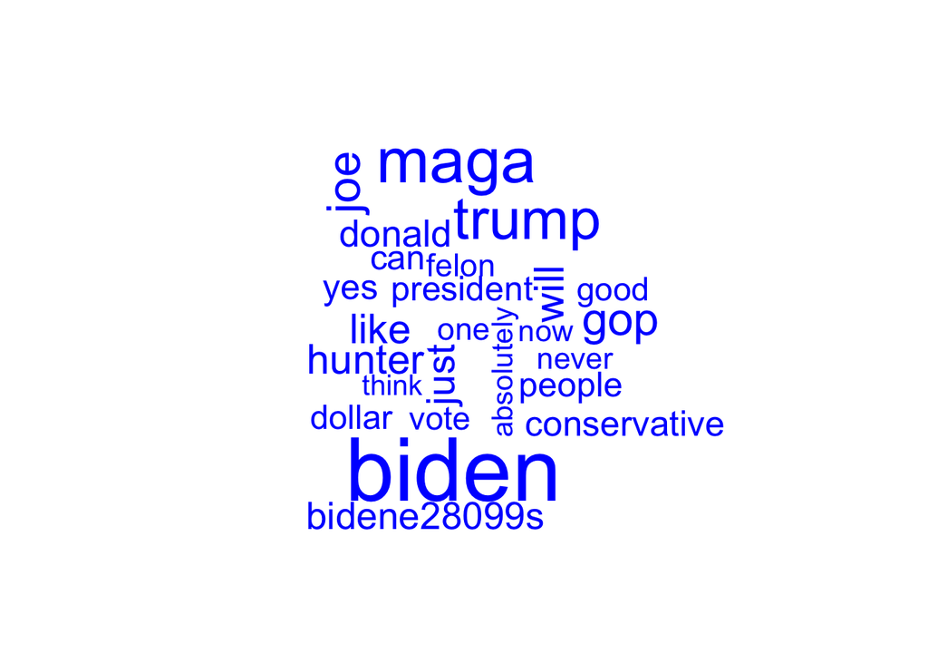

```r
tfidf_freq <- rowSums(tfidf_tdm_m)
tfidf_freq <- sort(tfidf_freq, decreasing = TRUE)

wordcloud(names(tfidf_freq), tfidf_freq, max.words = 25, color = "blue")
```

## Sentiment Analysis - Polarity (fast & dirty)

```r
pol <- polarity(df_cleaned_text$text[1:891])
summary(pol$all$polarity)
```

```
##     Min.  1st Qu.   Median     Mean  3rd Qu.     Max.
## -1.84327 -0.31623  0.00000 -0.05824  0.20000  1.26491
```

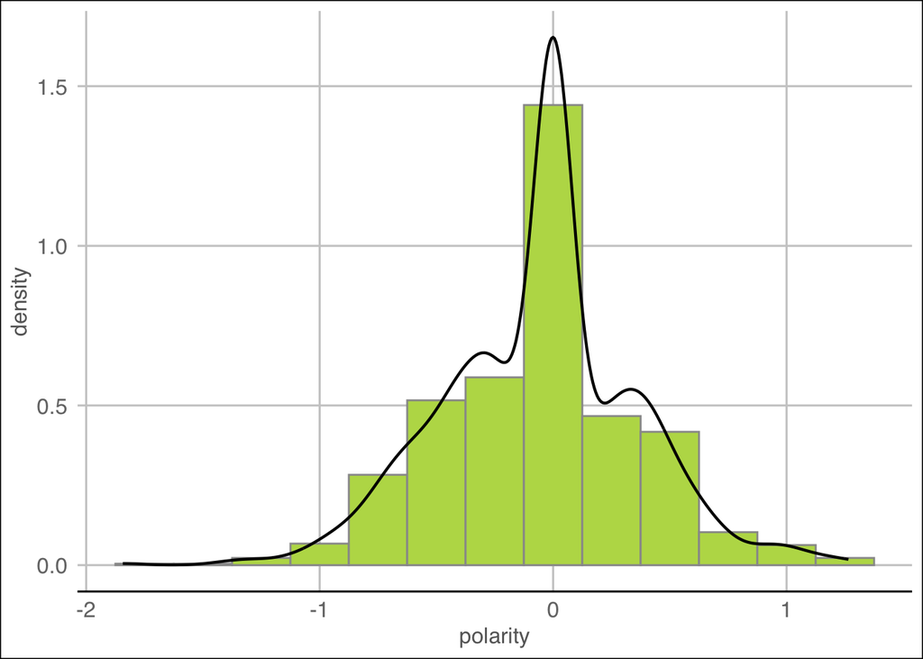

```r
ggplot(pol$all, aes(x = polarity, y = after_stat(density))) +
  geom_histogram(binwidth = 0.25, fill = "#bada55", colour = "grey60") +
  geom_density(linewidth = 0.75) +
  theme_gdocs()
```

## Sentiment Analysis - Polarity (tidy)

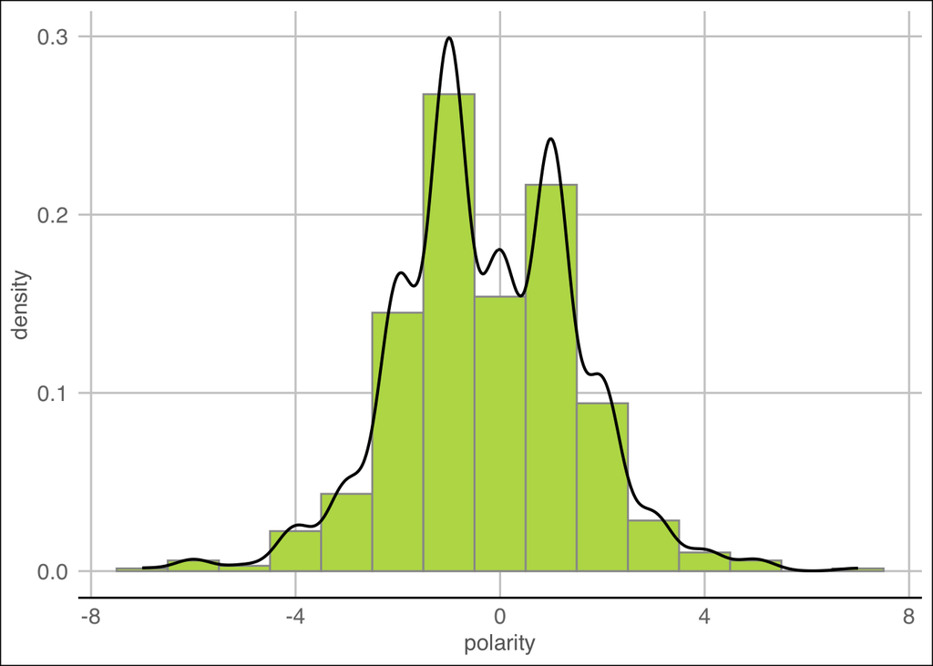

```r
tidy_texts <- df_cleaned_text %>%
  unnest_tokens(word, text)

tidy_texts <- tidy_texts %>%
  group_by(id) %>%
  mutate(original_word_order = seq_along(word))

bing <- get_sentiments("bing")

pos_neg <- tidy_texts %>%
  inner_join(bing, by = c("word" = "word")) %>%
  count(sentiment) %>%
  pivot_wider(names_from = sentiment, values_from = n, values_fill = 0) %>%
  mutate(polarity = positive - negative)

ggplot(pos_neg, aes(x = polarity, y = after_stat(density))) +
  geom_histogram(binwidth = 1, fill = "#bada55", colour = "grey60") +
  geom_density(linewidth = 0.75) +
  theme_gdocs()
```

## Organize positive/negative words

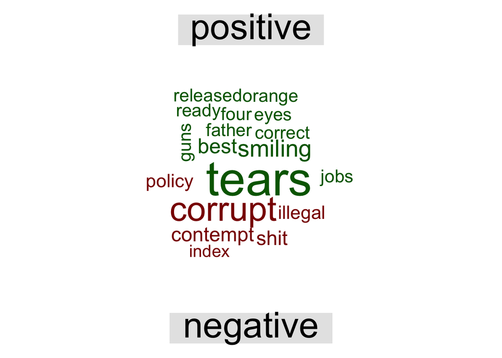

```r
pos_terms <- df_cleaned_text %>%
  mutate(polarity = pol$all$polarity) %>%
  filter(polarity > 0) %>%
  pull(text) %>%
  paste(collapse = " ")

neg_terms <- df_cleaned_text %>%
  mutate(polarity = pol$all$polarity) %>%
  filter(polarity < 0) %>%
  pull(text) %>%
  paste(collapse = " ")

all_corp <- c(pos_terms, neg_terms) %>%
  VectorSource() %>%
  VCorpus()

all_tdm <- TermDocumentMatrix(all_corp,
                              control = list(weighting = weightTfIdf))

all_tdm_m <- as.matrix(all_tdm)
colnames(all_tdm_m) <- c("positive", "negative")
all_tdm_df <- as.data.frame(all_tdm_m)
all_tdm_df$term <- rownames(all_tdm_df)

comparison.cloud(all_tdm_m, max.words = 18, colors = c("darkgreen","darkred"))
```

## Bar plot of positive terms

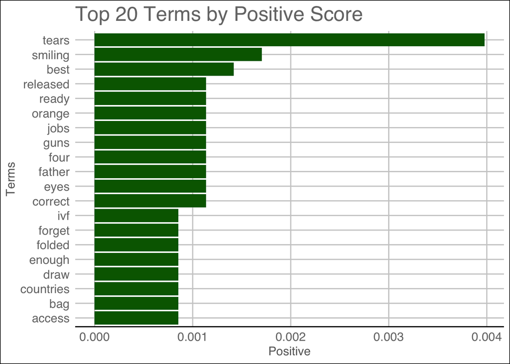

```r
order_by_pos <- all_tdm_df %>%
  arrange(desc(positive)) %>%
  head(20)

ggplot(order_by_pos, aes(x = reorder(term, positive), y = positive)) +
  geom_bar(stat = "identity", fill = "darkgreen") +
  labs(title = "Top 20 Terms by Positive Score",
       x = "Terms",
       y = "Positive") +
  coord_flip() +
  theme_gdocs()
```

## Bar plot of negative terms

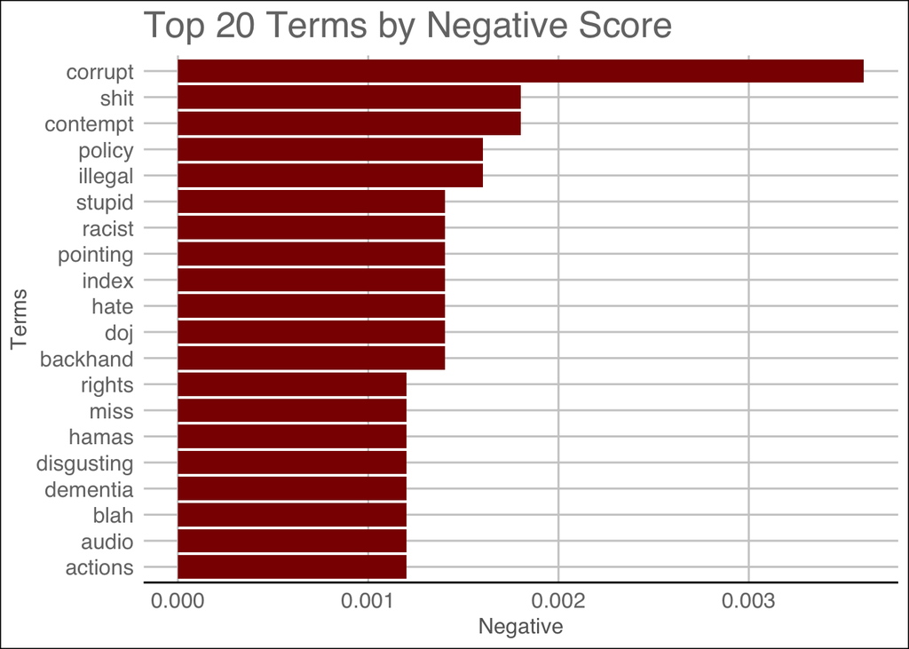

```r
order_by_neg <- all_tdm_df %>%
  arrange(desc(negative)) %>%
  head(20)

ggplot(order_by_neg, aes(x = reorder(term, negative), y = negative)) +
  geom_bar(stat = "identity", fill = "darkred") +
  labs(title = "Top 20 Terms by Negative Score",
       x = "Terms",
       y = "Negative") +
  coord_flip() +
  theme_gdocs()
```

## Polarity vs Word effort

```r
pos_neg_pol <- tidy_texts %>%
  count(id) %>%
  inner_join(pos_neg) %>%
  mutate(pol = ifelse(polarity >= 0, "Positive", "Negative"))
```

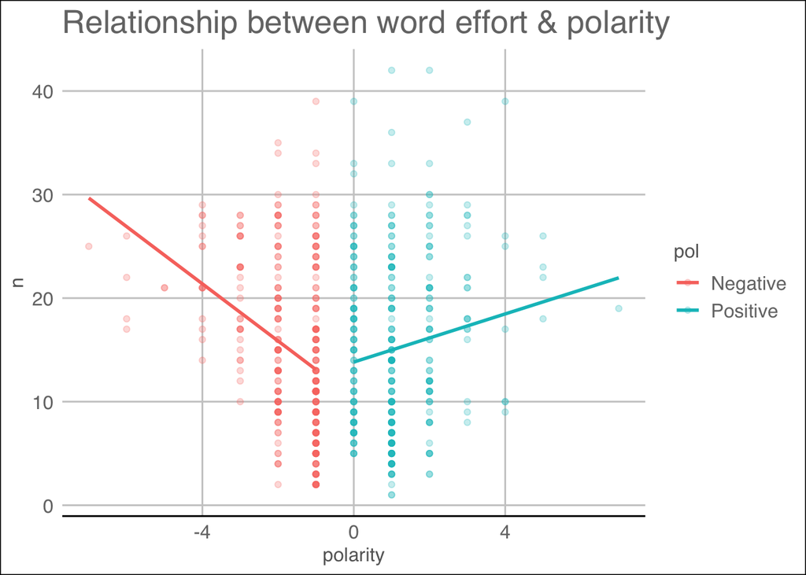

```r
ggplot(pos_neg_pol, aes(polarity, n, color = pol)) +
  geom_point(alpha = 0.25) +
  geom_smooth(method = "lm", se = FALSE) +
  theme_gdocs() +
  ggtitle("Relationship between word effort & polarity")
```

## Sentiment vs Like count

In order to better visualize the differences in each feature we applied logarithmic transformation to likes and retweets.

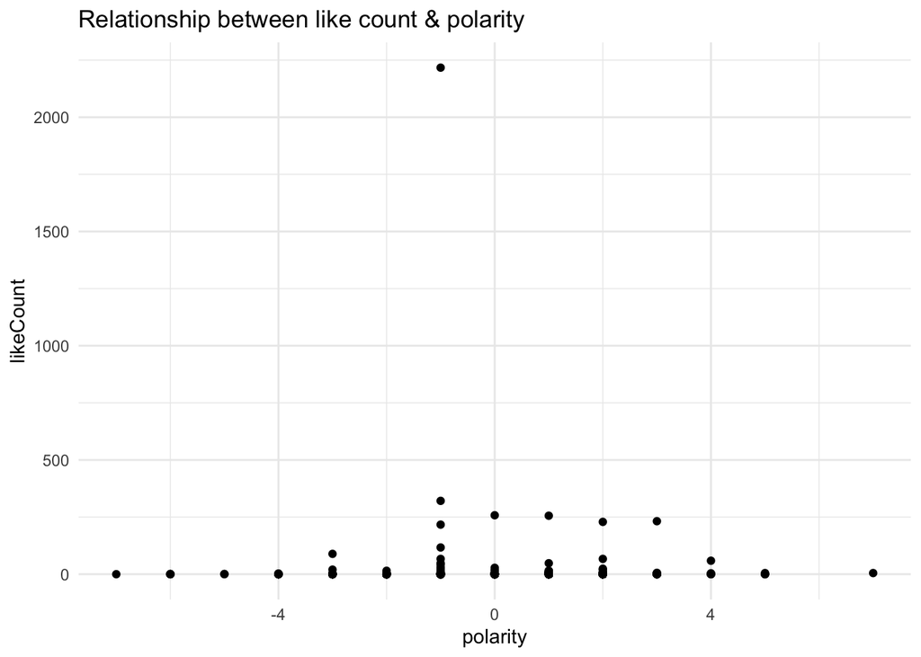

```r
df_sent <- df %>%
  inner_join(pos_neg, by = c("id" = "id")) %>%
  select(c(id, retweetCount, likeCount, polarity)) %>%
  mutate(likeLog = log(likeCount + 1)) %>%
  mutate(retweetLog = log(retweetCount + 1))

ggplot(df_sent, aes(x = polarity, y = likeCount)) +
  geom_point() +
  theme_minimal() +
  ggtitle("Relationship between like count & polarity")
```

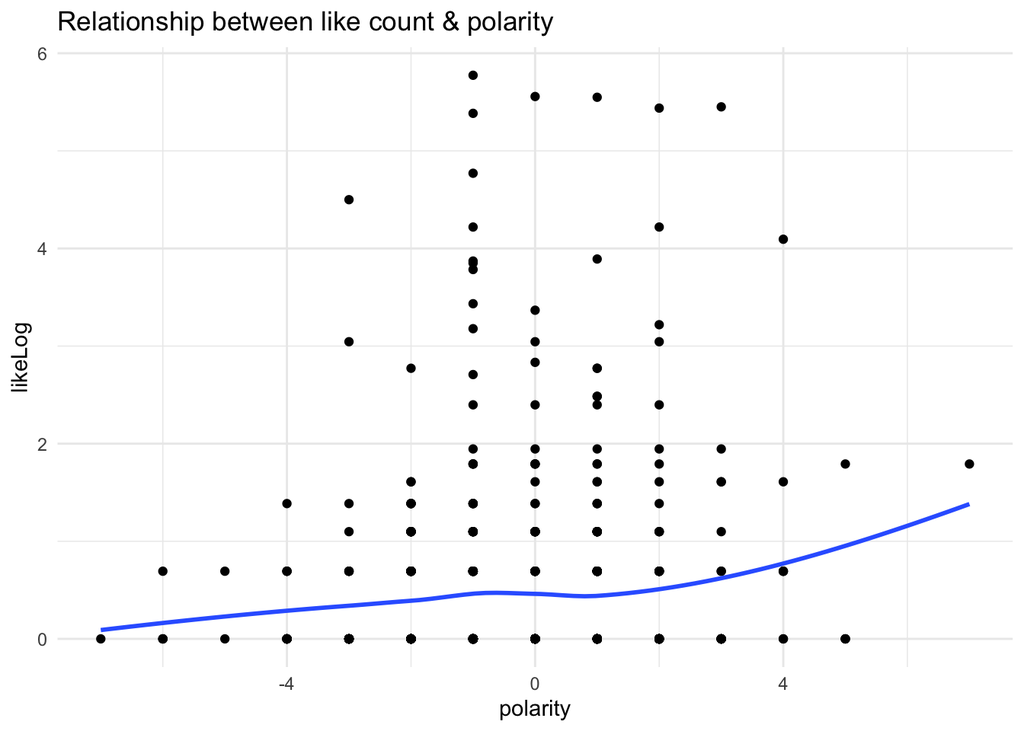

```r
df_sent_outlier <- df_sent %>%
  filter(likeCount < 2000)

ggplot(df_sent_outlier, aes(x = polarity, y = likeLog)) +
  geom_point() +
  geom_smooth(method = "loess", se = FALSE) +
  theme_minimal() +
  ggtitle("Relationship between like count & polarity")
```

## Sentiment vs Retweet count

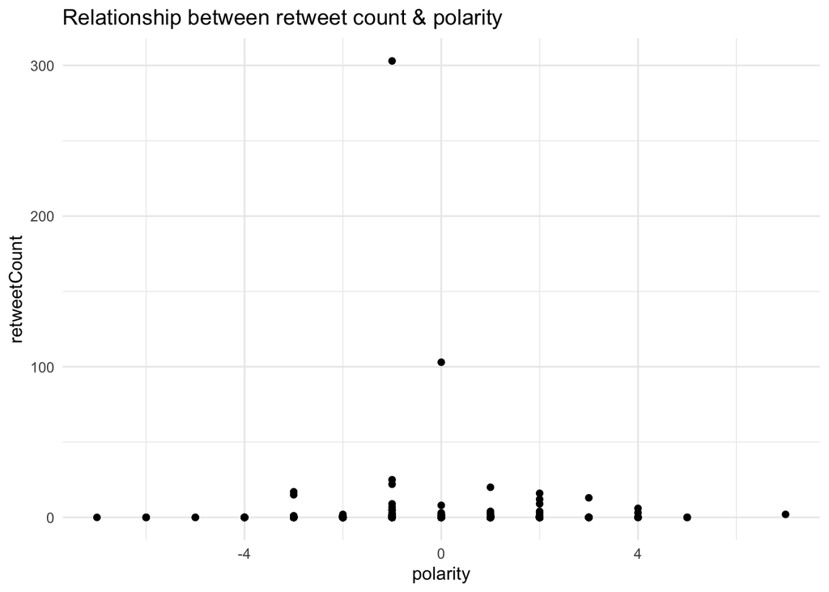

```r
ggplot(df_sent, aes(x = polarity, y = retweetCount)) +
  geom_point() +
  theme_minimal() +
  ggtitle("Relationship between retweet count & polarity")
```

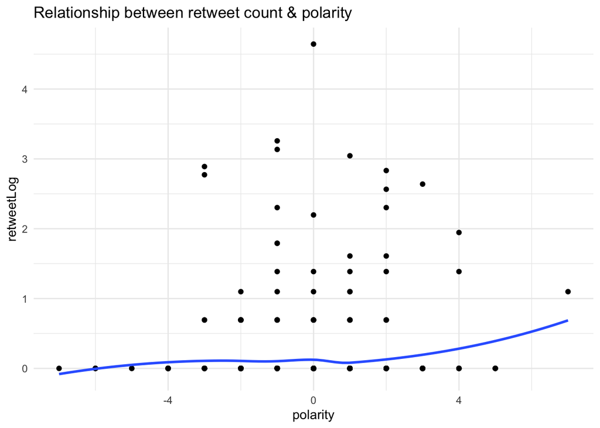

```r
df_sent_outlier <- df_sent %>%
  filter(likeCount < 300)

ggplot(df_sent_outlier, aes(x = polarity, y = retweetLog)) +
  geom_point() +
  geom_smooth(method = "loess", se = FALSE) +
  theme_minimal() +
  ggtitle("Relationship between retweet count & polarity")
```

## Sentiment vs Epoch

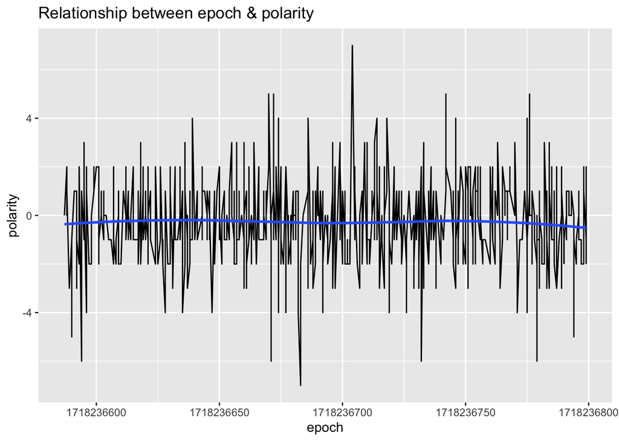

```r
df_sent_epoch <- df %>%
  inner_join(pos_neg, by = c("id" = "id")) %>%
  select(c(id, polarity, epoch))

ggplot(df_sent_epoch, aes(x = epoch, y = polarity)) +
  geom_line() +
  geom_smooth(method = "loess", se = FALSE) +
  ggtitle("Relationship between epoch & polarity")
```